# IE360 HW2

Recep Talha Bölükbaş

06 05 2021

#Time Series Regression for Predicting Macroeconomic Indicators

## Base of My Model

In this work, I will use CPI data of food and non-alcoholic beverages from EVDS and make a time series regression model with some regressors. As regressors I thought that USD-TRY exchange rate, consumer loan interest and total foreign currency reserves of CB are related with CPI and can be good regressors with high significancy at forecasting next month’s CPI value. I have data from “2012-04” to “2021-03” and will try to predict the CPI value of April 2021 at the end.First it requires some data manipulation steps. I plotted the data and look is there any trend or seasonality in my data.

## Required Library

```r
library(tidyverse)
library(lubridate)
library(zoo)
```

```r
library(ggplot2)
library(openxlsx)
require(data.table)
library(forecast)
```

## Data Manipulation and Model Building

We need to read the data from an excel file and then prepare it to plot.

```r
mydata = read.xlsx("C:\\Users\\rtbol\\Downloads\\hw2 EVDS.xlsx")
class(mydata)
```

```
## [1] "data.frame"
```

```r
mydatatable = data.table(mydata)
is.data.table(mydatatable)
```

```
## [1] TRUE
```

```r
head(mydatatable,13)
```

```
##       Tarih TP.DK.USD.A.YTL TP.KTF10 TP.AB.C2 TP.FG.J01
##  1: 2012-04        1.779840  18.5350    80206    218.12
##  2: 2012-05        1.796955  18.3475    78595    212.89
##  3: 2012-06        1.816071  18.0980    83050    205.61
##  4: 2012-07        1.804886  17.8650    84324    206.36
##  5: 2012-08        1.785840  17.4780    92996    209.37
##  6: 2012-09        1.795630  16.6450    94800    213.86
##  7: 2012-10        1.794140  16.3100    96678    217.42
##  8: 2012-11        1.785450  15.7260   100166    217.16
##  9: 2012-12        1.779090  14.2500   100320    220.53
## 10: 2013-01        1.763859  14.0550   103550    229.35
## 11: 2013-02        1.769925  13.7550   104437    231.38
## 12: 2013-03        1.807195  13.5240   105650    236.09
## 13: 2013-04        1.796471  13.4500   113269    233.02
```

After this we can look 1 year behaviour and all 9 years behaviour of the data

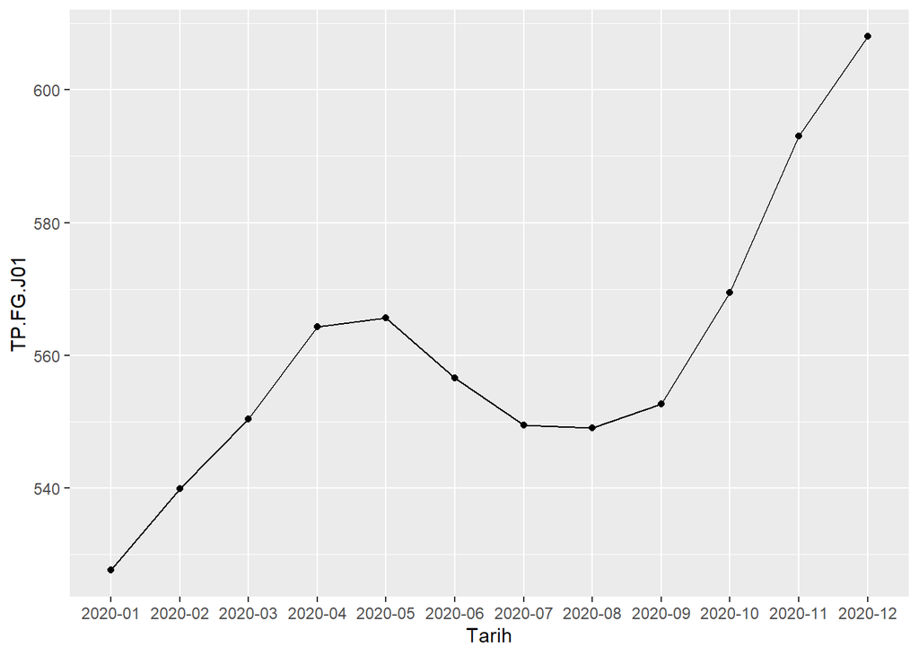

```r
ggplot(mydatatable[Tarih <= "2020-12" & Tarih >= "2020-01"],aes(x=Tarih,y=TP.FG.J01)) + geom_line(group=1) + geom_point()
```

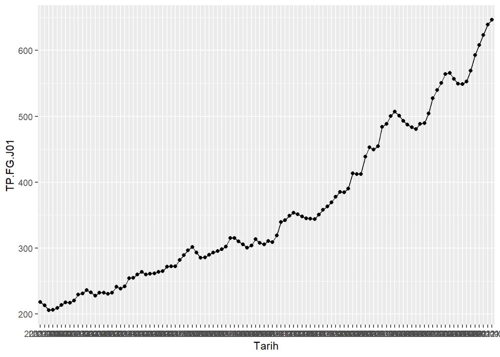

```r
ggplot(mydatatable,aes(x=Tarih,y=TP.FG.J01)) + geom_line(group=1) + geom_point()
```

We can see that there is a increasing linear trend in the all data and some little seasonality in one-year graph. First I added the trend in my data and made my first model ts_reg with only trend.

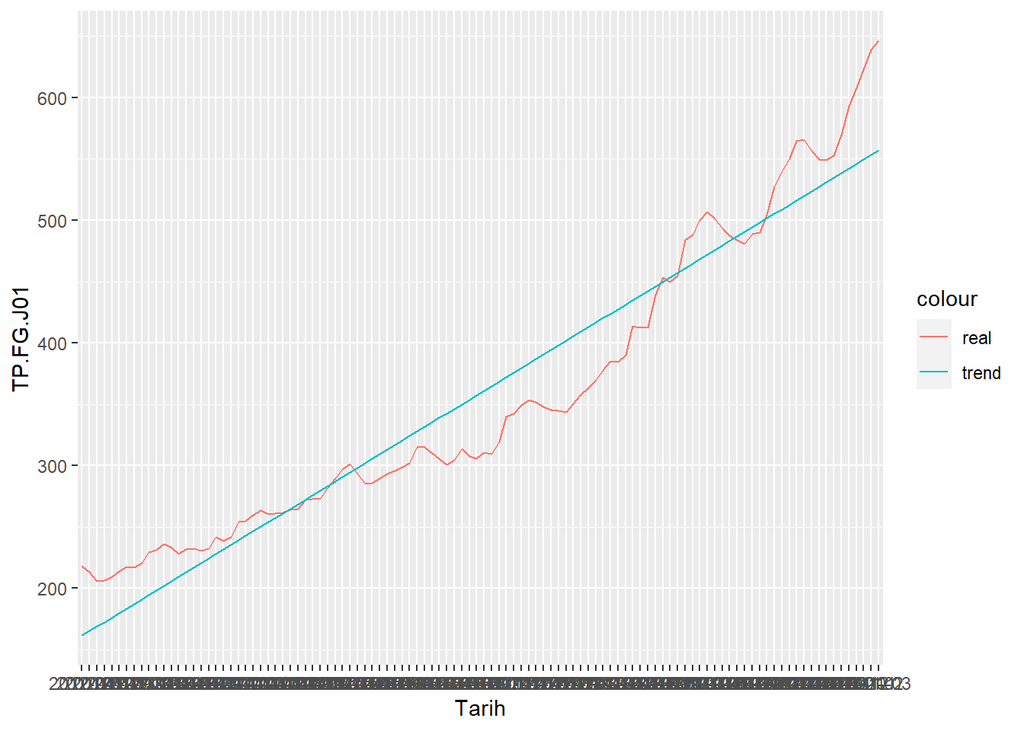

```r
mydatatable[,trend:=1:.N]
ts_reg=lm(TP.FG.J01~trend,mydatatable)
mydatatable[,trend_constant:=predict(ts_reg,mydatatable)]
ggplot(mydatatable ,aes(x=Tarih)) + geom_line(group=1,aes(y=TP.FG.J01,color='real')) + geom_line(group=1,aes(y=trend_constant,color='trend'))
```

```r
summary(ts_reg)
```

```
##
## Call:
## lm(formula = TP.FG.J01 ~ trend, data = mydatatable)
##
## Residuals:
##     Min      1Q  Median      3Q     Max
## -57.975 -27.245   1.475  24.073  89.348
##
## Coefficients:
##             Estimate Std. Error t value Pr(>|t|)
## (Intercept) 157.7270     6.5013   24.26   <2e-16 ***
## trend         3.6975     0.1035   35.71   <2e-16 ***
## ---
## Signif. codes:  0 '***' 0.001 '**' 0.01 '*' 0.05 '.' 0.1 ' ' 1
##
## Residual standard error: 33.55 on 106 degrees of freedom
## Multiple R-squared:  0.9233, Adjusted R-squared:  0.9225
## F-statistic:  1275 on 1 and 106 DF,  p-value: < 2.2e-16
```

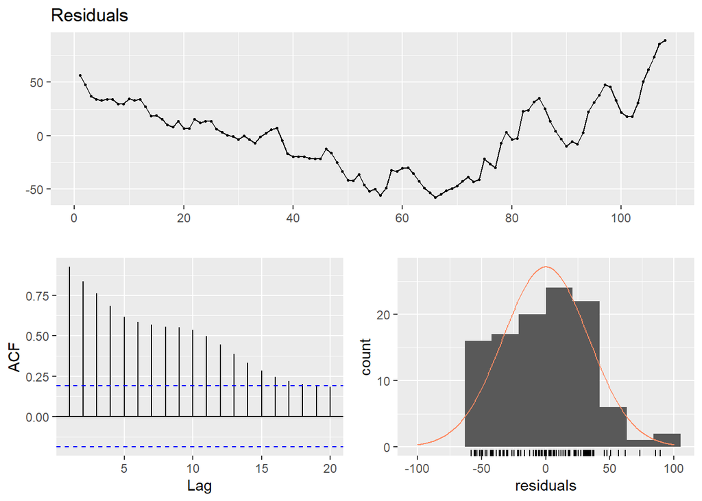

```
##
##  Breusch-Godfrey test for serial correlation of order up to 10
##
## data:  Residuals
## LM test = 100.69, df = 10, p-value < 2.2e-16
```

```r
checkresiduals(ts_reg)
```

In this step our trend variable is highly significant and model has 0.92 R-squared value. However when we check residuals, it can be seen that residuals are not fitting to basic assumptions and are highly correlated. Then I decided to add month variable because of little seasonality I found in one-year graph. First I made some arrangements on data.

```r
mydatatable <- mydatatable %>% mutate(Tarih = ym(Tarih))
mydatatable[,monthName:=as.character(lubridate::month(Tarih, label=T))]
mydatatable
```

```
##           Tarih TP.DK.USD.A.YTL TP.KTF10 TP.AB.C2 TP.FG.J01 trend
##   1: 2012-04-01        1.779840  18.5350    80206    218.12     1
##   2: 2012-05-01        1.796955  18.3475    78595    212.89     2
##   3: 2012-06-01        1.816071  18.0980    83050    205.61     3
##   4: 2012-07-01        1.804886  17.8650    84324    206.36     4
##   5: 2012-08-01        1.785840  17.4780    92996    209.37     5
##  ---
## 104: 2020-11-01        8.003324  21.0825    43898    593.07   104
## 105: 2020-12-01        7.721065  22.7600    49965    608.06   105
## 106: 2021-01-01        7.393975  22.8180    53366    623.16   106
## 107: 2021-02-01        7.072365  22.4200    54494    639.20   107
## 108: 2021-03-01        7.628235  22.6425    50893    646.41   108
##      trend_constant monthName
##   1:       161.4246       Nis
##   2:       165.1221       May
##   3:       168.8197       Haz
##   4:       172.5172       Tem
##   5:       176.2148       Ağu
##  ---
## 104:       542.2719       Kas
## 105:       545.9694       Ara
## 106:       549.6670       Oca
## 107:       553.3645       Şub
## 108:       557.0621       Mar
```

Then I made ts_reg2 with trend and months.

```r
ts_reg2=lm(TP.FG.J01~trend+monthName,mydatatable)
summary(ts_reg2)
```

```
##
## Call:
## lm(formula = TP.FG.J01 ~ trend + monthName, data = mydatatable)
##
## Residuals:
##     Min      1Q  Median      3Q     Max
## -55.348 -27.879   3.439  20.846  76.658
##
## Coefficients:
##              Estimate Std. Error t value Pr(>|t|)
## (Intercept)  148.0702    12.7858  11.581   <2e-16 ***
## trend          3.6879     0.1068  34.527   <2e-16 ***
## monthNameAra   6.9274    16.2186   0.427    0.670
## monthNameEki   4.5887    16.2144   0.283    0.778
## monthNameEyl   0.1777    16.2133   0.011    0.991
## monthNameHaz   8.1824    16.2144   0.505    0.615
## monthNameKas   3.9119    16.2161   0.241    0.810
## monthNameMar  23.3904    16.2302   1.441    0.153
## monthNameMay  12.3836    16.2161   0.764    0.447
## monthNameNis  19.1737    16.2186   1.182    0.240
## monthNameOca  18.5762    16.2218   1.145    0.255
## monthNameŞub  20.8205    16.2256   1.283    0.203
## monthNameTem   4.0723    16.2133   0.251    0.802
## ---
## Signif. codes:  0 '***' 0.001 '**' 0.01 '*' 0.05 '.' 0.1 ' ' 1
##
## Residual standard error: 34.39 on 95 degrees of freedom
## Multiple R-squared:  0.9277, Adjusted R-squared:  0.9186
## F-statistic: 101.6 on 12 and 95 DF,  p-value: < 2.2e-16
```

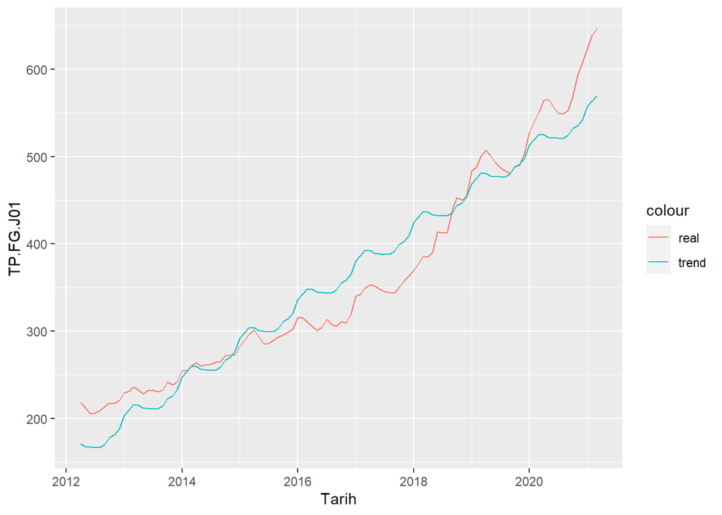

```r
mydatatable[,trend_constant_month:=predict(ts_reg2,mydatatable)]
ggplot(mydatatable ,aes(x=Tarih)) +
  geom_line(aes(y=TP.FG.J01,color='real')) +
  geom_line(aes(y=trend_constant_month,color='trend'))
```

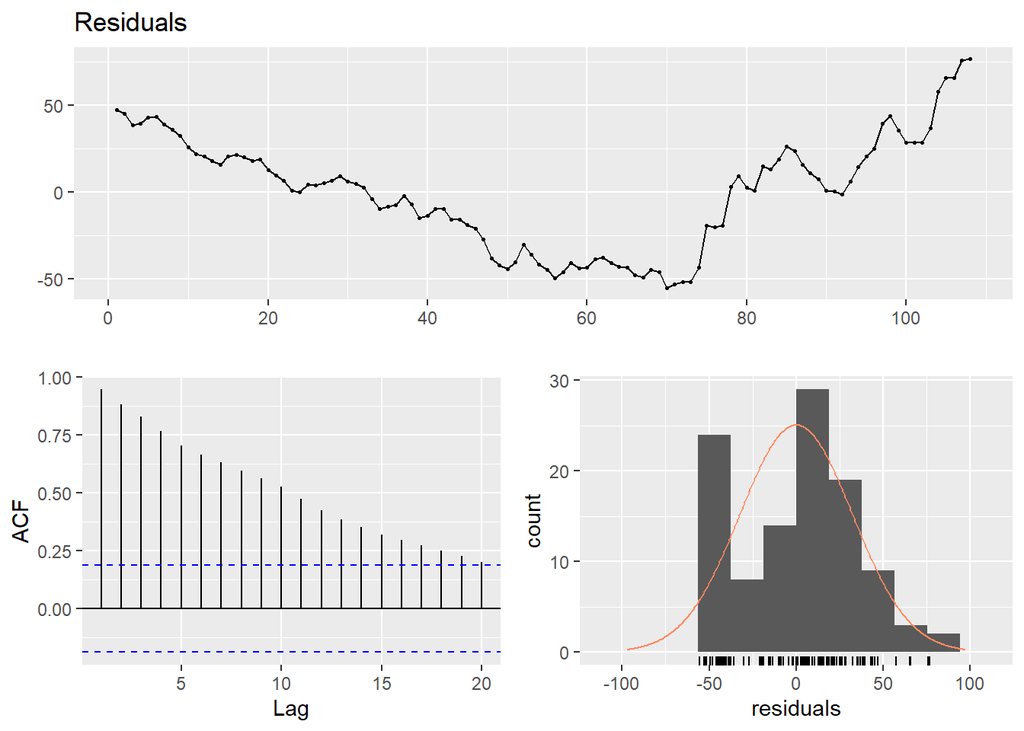

```
##
##  Breusch-Godfrey test for serial correlation of order up to 16
##
## data:  Residuals
## LM test = 103.69, df = 16, p-value = 7.02e-15
```

```r
checkresiduals(ts_reg2)
```

In this step there was not much change in my R-squared value and residuals. In summary month values were not significant but intercept was still highly significant and I decided to keep this in my model for next steps. First I added Exchange rate to model and create ts_reg3 with trend+month+exchange rate

```r
ts_reg3=lm(TP.FG.J01~trend+monthName+TP.DK.USD.A.YTL,mydatatable)
summary(ts_reg3)
```

```
##
## Call:
## lm(formula = TP.FG.J01 ~ trend + monthName + TP.DK.USD.A.YTL,
##     data = mydatatable)
##
## Residuals:
##     Min      1Q  Median      3Q     Max
## -54.480  -8.468   1.179   8.977  51.922
##
## Coefficients:
##                 Estimate Std. Error t value Pr(>|t|)
## (Intercept)     108.0606     6.2766  17.217  < 2e-16 ***
## trend             0.8178     0.1608   5.086 1.86e-06 ***
## monthNameAra     10.3632     7.4899   1.384 0.169754
## monthNameEki      2.4146     7.4866   0.323 0.747777
## monthNameEyl     -3.8120     7.4883  -0.509 0.611904
## monthNameHaz     11.6118     7.4880   1.551 0.124327
## monthNameKas      4.9131     7.4867   0.656 0.513271
## monthNameMar     28.6850     7.4984   3.826 0.000235 ***
## monthNameMay     12.6576     7.4866   1.691 0.094207 .
## monthNameNis     21.1975     7.4885   2.831 0.005680 **
## monthNameOca     23.3971     7.4936   3.122 0.002385 **
## monthNameŞub     30.1978     7.5076   4.022 0.000116 ***
## monthNameTem      9.6623     7.4912   1.290 0.200278
## TP.DK.USD.A.YTL  51.1169     2.7257  18.754  < 2e-16 ***
## ---
## Signif. codes:  0 '***' 0.001 '**' 0.01 '*' 0.05 '.' 0.1 ' ' 1
##
## Residual standard error: 15.88 on 94 degrees of freedom
## Multiple R-squared:  0.9848, Adjusted R-squared:  0.9826
## F-statistic:   467 on 13 and 94 DF,  p-value: < 2.2e-16
```

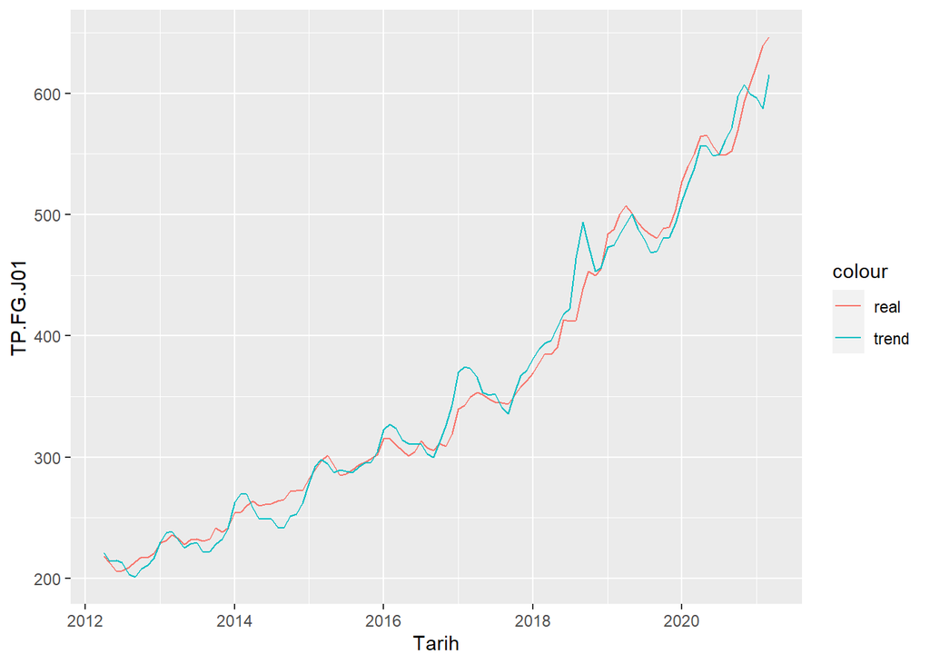

```r
mydatatable[,trend_constant_month_usd:=predict(ts_reg3,mydatatable)]
ggplot(mydatatable ,aes(x=Tarih)) +
  geom_line(aes(y=TP.FG.J01,color='real')) +
  geom_line(aes(y=trend_constant_month_usd,color='trend'))
```

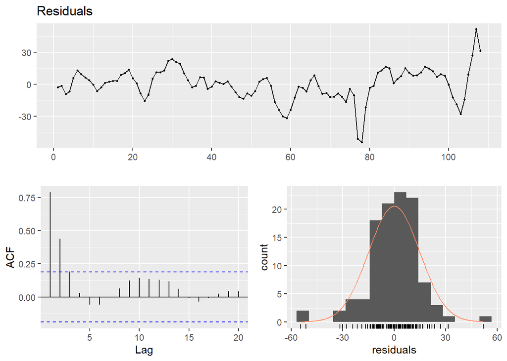

```
##
##  Breusch-Godfrey test for serial correlation of order up to 17
##
## data:  Residuals
## LM test = 84.085, df = 17, p-value = 7.153e-11
```

```r
checkresiduals(ts_reg3)
```

After this step my model became much better my residuals were closer to normal distribution with zero mean and constant variance. Then I built models ts_reg4 with trend+month+exchange+interest and ts_reg5 with trend+month+exchange+interest+reserves.

```r
ts_reg4=lm(TP.FG.J01~trend+monthName+TP.DK.USD.A.YTL+TP.KTF10,mydatatable)
summary(ts_reg4)
```

```
##
## Call:
## lm(formula = TP.FG.J01 ~ trend + monthName + TP.DK.USD.A.YTL +
##     TP.KTF10, data = mydatatable)
##
## Residuals:
##     Min      1Q  Median      3Q     Max
## -44.941  -7.485   0.188   8.283  51.908
##
## Coefficients:
##                 Estimate Std. Error t value Pr(>|t|)
## (Intercept)     118.9814     7.4884  15.889  < 2e-16 ***
## trend             0.8252     0.1564   5.275 8.62e-07 ***
## monthNameAra     10.3442     7.2857   1.420 0.159010
## monthNameEki      3.0606     7.2870   0.420 0.675448
## monthNameEyl     -3.2864     7.2871  -0.451 0.653049
## monthNameHaz     11.4044     7.2843   1.566 0.120833
## monthNameKas      5.2108     7.2836   0.715 0.476143
## monthNameMar     27.9038     7.3005   3.822 0.000239 ***
## monthNameMay     12.1358     7.2854   1.666 0.099123 .
## monthNameNis     20.6845     7.2871   2.839 0.005565 **
## monthNameOca     23.2810     7.2894   3.194 0.001917 **
## monthNameŞub     29.8122     7.3045   4.081 9.46e-05 ***
## monthNameTem      9.4180     7.2876   1.292 0.199440
## TP.DK.USD.A.YTL  52.1095     2.6805  19.441  < 2e-16 ***
## TP.KTF10         -0.8176     0.3246  -2.519 0.013487 *
## ---
## Signif. codes:  0 '***' 0.001 '**' 0.01 '*' 0.05 '.' 0.1 ' ' 1
##
## Residual standard error: 15.45 on 93 degrees of freedom
## Multiple R-squared:  0.9857, Adjusted R-squared:  0.9836
## F-statistic: 458.8 on 14 and 93 DF,  p-value: < 2.2e-16
```

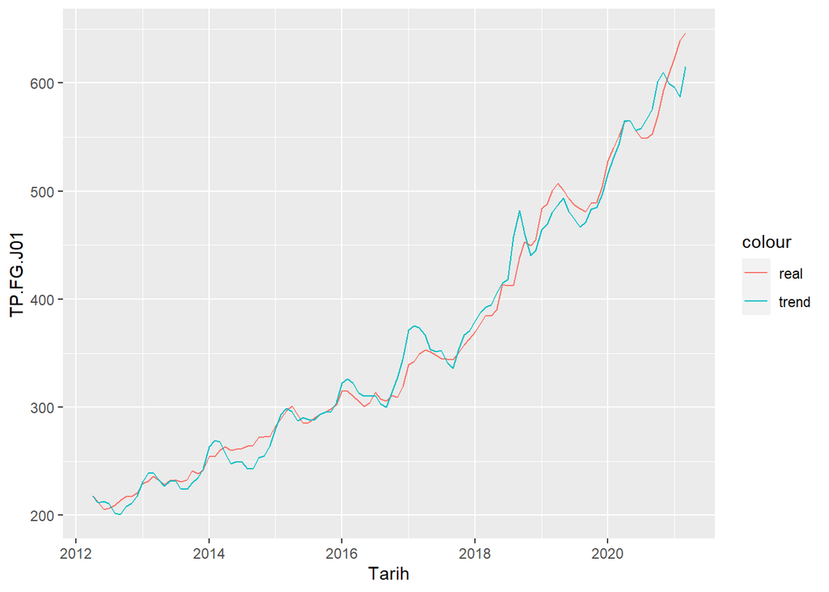

```r
mydatatable[,trend_constant_month_usd_interest:=predict(ts_reg4,mydatatable)]
ggplot(mydatatable ,aes(x=Tarih)) +
  geom_line(aes(y=TP.FG.J01,color='real')) +
  geom_line(aes(y=trend_constant_month_usd_interest,color='trend'))
```

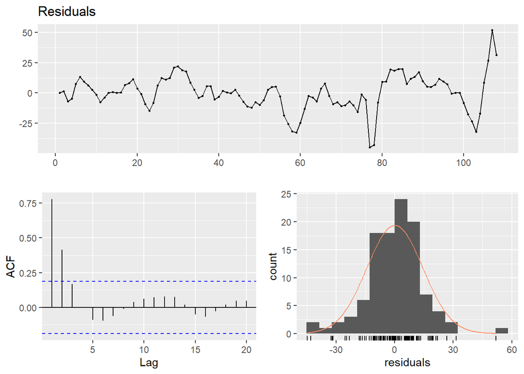

```
##
##  Breusch-Godfrey test for serial correlation of order up to 18
##
## data:  Residuals
## LM test = 84.005, df = 18, p-value = 1.691e-10
```

```r
checkresiduals(ts_reg4)
```

```r
ts_reg5=lm(TP.FG.J01~trend+monthName+TP.DK.USD.A.YTL+TP.KTF10+TP.AB.C2,mydatatable)
summary(ts_reg5)
```

```
##
## Call:
## lm(formula = TP.FG.J01 ~ trend + monthName + TP.DK.USD.A.YTL +
##     TP.KTF10 + TP.AB.C2, data = mydatatable)
##
## Residuals:
##     Min      1Q  Median      3Q     Max
## -48.556  -6.407   0.340   7.809  53.638
##
## Coefficients:
##                   Estimate Std. Error t value Pr(>|t|)
## (Intercept)     49.5602557 31.4822800   1.574 0.118868
## trend            0.6028620  0.1817714   3.317 0.001306 **
## monthNameAra    10.1008711  7.1295315   1.417 0.159929
## monthNameEki     1.5291663  7.1619254   0.214 0.831399
## monthNameEyl    -3.8906307  7.1350479  -0.545 0.586877
## monthNameHaz    12.7762678  7.1529489   1.786 0.077369 .
## monthNameKas     3.4366704  7.1694505   0.479 0.632828
## monthNameMar    28.3953704  7.1464844   3.973 0.000141 ***
## monthNameMay    13.0297358  7.1392951   1.825 0.071235 .
## monthNameNis    22.0769575  7.1565104   3.085 0.002689 **
## monthNameOca    22.8535567  7.1348089   3.203 0.001868 **
## monthNameŞub    29.4437639  7.1489593   4.119 8.32e-05 ***
## monthNameTem    11.1099069  7.1694826   1.550 0.124668
## TP.DK.USD.A.YTL 60.8406366  4.6591304  13.058  < 2e-16 ***
## TP.KTF10        -0.7860132  0.3179385  -2.472 0.015266 *
## TP.AB.C2         0.0005393  0.0002378   2.267 0.025710 *
## ---
## Signif. codes:  0 '***' 0.001 '**' 0.01 '*' 0.05 '.' 0.1 ' ' 1
##
## Residual standard error: 15.11 on 92 degrees of freedom
## Multiple R-squared:  0.9865, Adjusted R-squared:  0.9843
## F-statistic: 447.6 on 15 and 92 DF,  p-value: < 2.2e-16
```

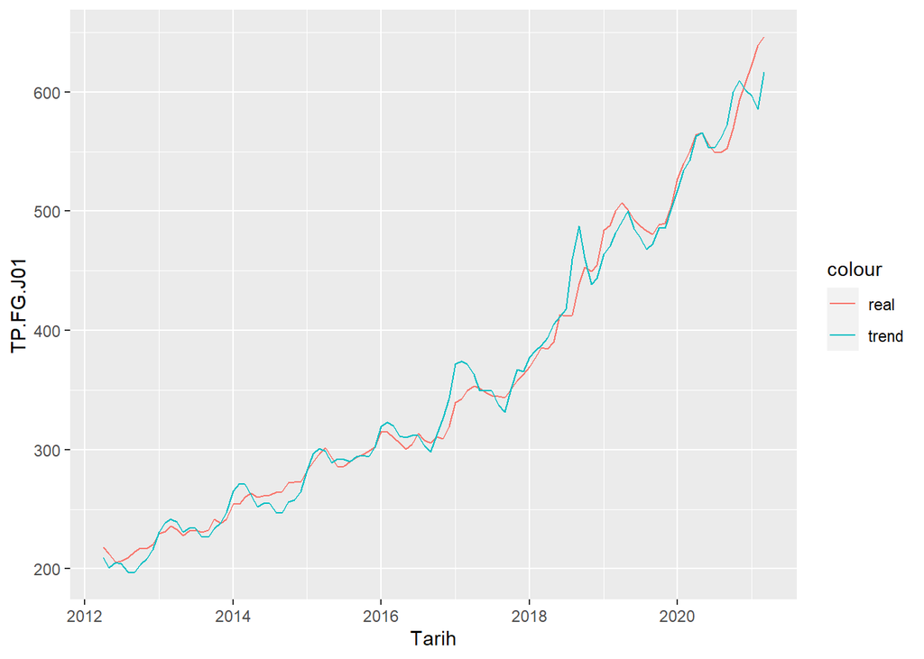

```r
mydatatable[,trend_constant_month_usd_reserves:=predict(ts_reg5,mydatatable)]
ggplot(mydatatable ,aes(x=Tarih)) +
  geom_line(aes(y=TP.FG.J01,color='real')) +
  geom_line(aes(y=trend_constant_month_usd_reserves,color='trend'))
```

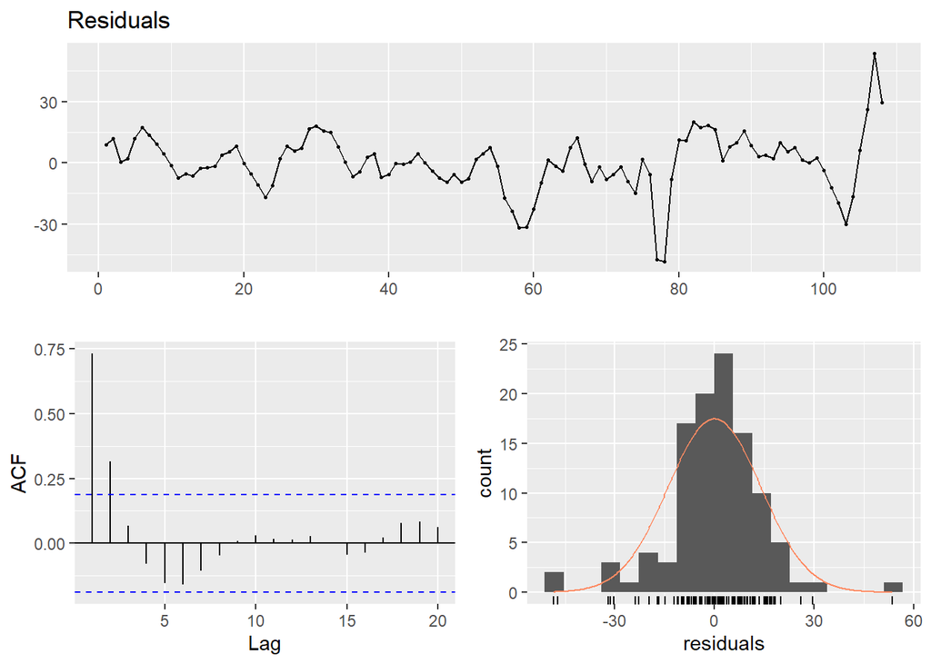

```
##
##  Breusch-Godfrey test for serial correlation of order up to 19
##
## data:  Residuals
## LM test = 77.139, df = 19, p-value = 5.759e-09
```

```r
checkresiduals(ts_reg5)
```

After these steps our regressors were significant and model were working well. In residuals there were high correlation in lag1 and lag2. These correlation values can be ignored but I want to add these lagged variables to make model better. ts_reg6 is the best model I have reached during my work.

```r
ts_reg6=lm(TP.FG.J01~trend+monthName+TP.DK.USD.A.YTL+TP.KTF10+TP.AB.C2+lag(TP.FG.J01,1)+lag(TP.FG.J01,2),mydatatable)
summary(ts_reg6)
```

```
##
## Call:
## lm(formula = TP.FG.J01 ~ trend + monthName + TP.DK.USD.A.YTL +
##     TP.KTF10 + TP.AB.C2 + lag(TP.FG.J01, 1) + lag(TP.FG.J01,
##     2), data = mydatatable)
##
## Residuals:
##     Min      1Q  Median      3Q     Max
## -9.9107 -2.9056  0.0006  2.3810 18.1685
##
## Coefficients:
##                     Estimate Std. Error t value Pr(>|t|)
## (Intercept)       -8.442e+00  1.240e+01  -0.681  0.49779
## trend              1.184e-02  6.863e-02   0.172  0.86347
## monthNameAra       6.727e+00  2.493e+00   2.698  0.00837 **
## monthNameEki       5.957e+00  2.520e+00   2.364  0.02028 *
## monthNameEyl       2.611e+00  2.489e+00   1.049  0.29690
## monthNameHaz       3.019e+00  2.526e+00   1.195  0.23536
## monthNameKas       1.121e+00  2.597e+00   0.432  0.66713
## monthNameMar       8.807e+00  2.636e+00   3.341  0.00123 **
## monthNameMay      -9.119e-01  2.613e+00  -0.349  0.72795
## monthNameNis       5.225e+00  2.686e+00   1.945  0.05492 .
## monthNameOca       1.520e+01  2.565e+00   5.928 5.89e-08 ***
## monthNameŞub       6.662e+00  2.951e+00   2.258  0.02642 *
## monthNameTem       2.341e+00  2.514e+00   0.931  0.35441
## TP.DK.USD.A.YTL    1.311e+01  2.541e+00   5.160 1.51e-06 ***
## TP.KTF10          -9.461e-02  1.163e-01  -0.813  0.41830
## TP.AB.C2           1.850e-04  9.469e-05   1.953  0.05394 .
## lag(TP.FG.J01, 1)  1.054e+00  9.601e-02  10.976  < 2e-16 ***
## lag(TP.FG.J01, 2) -2.178e-01  9.215e-02  -2.364  0.02029 *
## ---
## Signif. codes:  0 '***' 0.001 '**' 0.01 '*' 0.05 '.' 0.1 ' ' 1
##
## Residual standard error: 5.243 on 88 degrees of freedom
##   (2 observations deleted due to missingness)
## Multiple R-squared:  0.9984, Adjusted R-squared:  0.9981
## F-statistic:  3231 on 17 and 88 DF,  p-value: < 2.2e-16
```

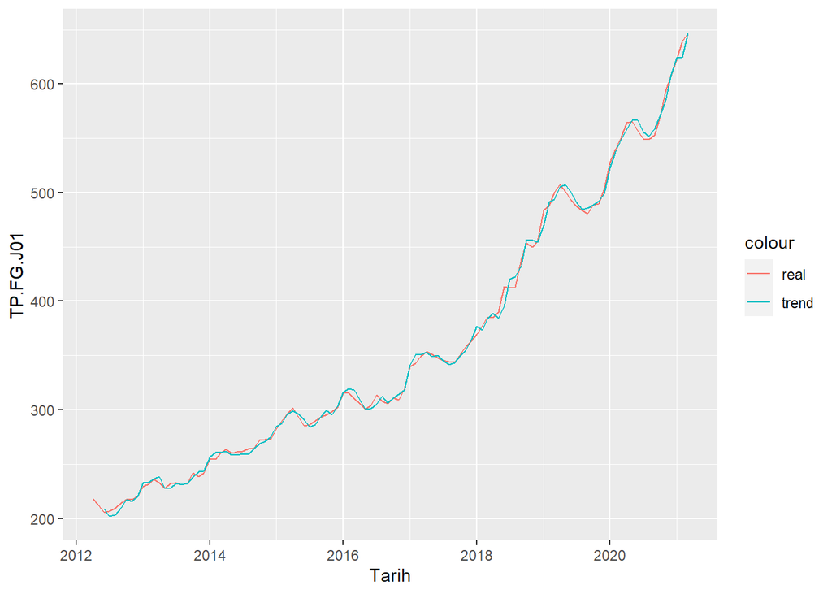

```r
mydatatable[,trend_constant_month_usd_reserves_lagged:=predict(ts_reg6,mydatatable)]
ggplot(mydatatable ,aes(x=Tarih)) +
  geom_line(aes(y=TP.FG.J01,color='real')) +
  geom_line(aes(y=trend_constant_month_usd_reserves_lagged,color='trend'))
```

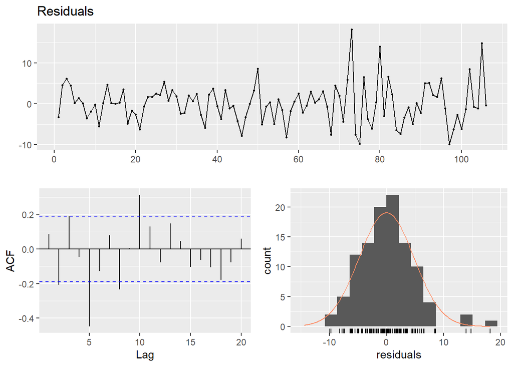

```
##
##  Breusch-Godfrey test for serial correlation of order up to 21
##
## data:  Residuals
## LM test = 48.784, df = 21, p-value = 0.0005372
```

```r
checkresiduals(ts_reg6)
```

Now my work is done actually. My adjusted R-squared value is 0.9981 most of my regressors have significancy and residuals are less correlated and very close to normal distribution with 0 mean and constant variance. However for forecasting 04-2021 value there is no values of regressors in the model for 04-2021. Then I tried to look cross-correlations of CPI values and other regressors one-by-one and decided to lag index in the negative side which has the most correlation.

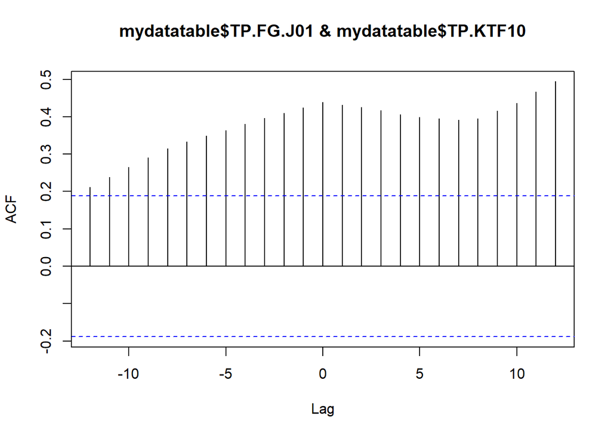

```r
ccf(mydatatable$TP.FG.J01,mydatatable$TP.KTF10,12)
```

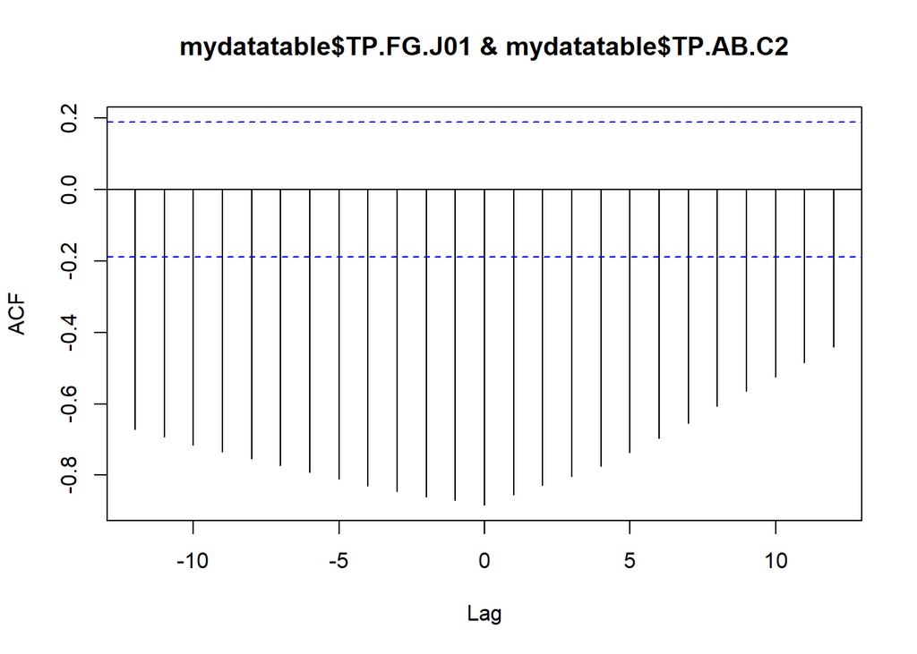

```r
ccf(mydatatable$TP.FG.J01,mydatatable$TP.AB.C2,12)
```

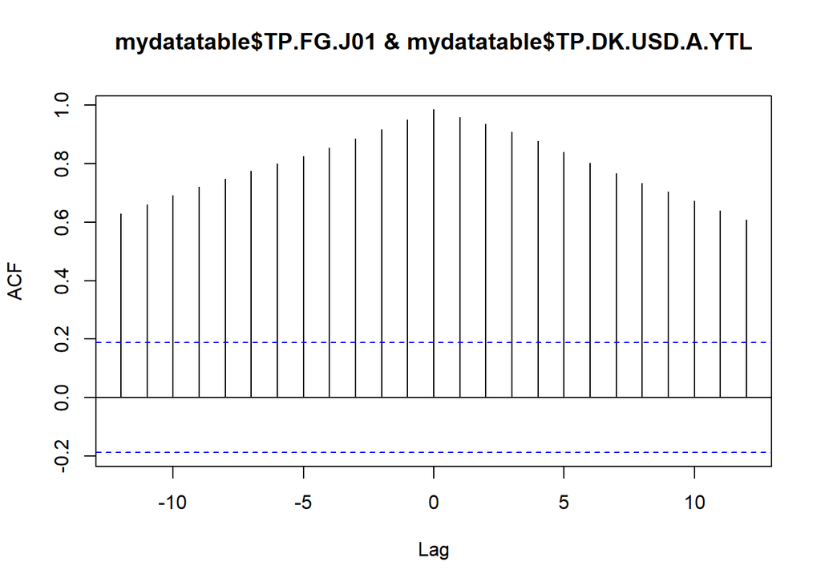

```r
ccf(mydatatable$TP.FG.J01,mydatatable$TP.DK.USD.A.YTL,12)
```

All of them has biggest correlation value in the lag1 in negative side.Then I build ts_reg7 with trend+month+lagged regressors+lagged variables.

```r
ts_reg7=lm(TP.FG.J01~trend+monthName+lag(TP.DK.USD.A.YTL,1)+lag(TP.KTF10,1)+lag(TP.AB.C2,1)+lag(TP.FG.J01,1)+lag(TP.FG.J01,2),mydatatable)
```

Then I added new row to my data table for 04-2021 and fill this row with values which I know already (trend and month).

```r
mydatatable=rbind(mydatatable,data.table(monthName=as.factor("Nis")),fill=T)
mydatatable
```

```
##           Tarih TP.DK.USD.A.YTL TP.KTF10 TP.AB.C2 TP.FG.J01 trend
##   1: 2012-04-01        1.779840  18.5350    80206    218.12     1
##   2: 2012-05-01        1.796955  18.3475    78595    212.89     2
##   3: 2012-06-01        1.816071  18.0980    83050    205.61     3
##   4: 2012-07-01        1.804886  17.8650    84324    206.36     4
##   5: 2012-08-01        1.785840  17.4780    92996    209.37     5
##  ---
## 105: 2020-12-01        7.721065  22.7600    49965    608.06   105
## 106: 2021-01-01        7.393975  22.8180    53366    623.16   106
## 107: 2021-02-01        7.072365  22.4200    54494    639.20   107
## 108: 2021-03-01        7.628235  22.6425    50893    646.41   108
## 109:       <NA>              NA       NA       NA        NA    NA
##      trend_constant monthName trend_constant_month trend_constant_month_usd
##   1:       161.4246       Nis             170.9318                 221.0557
##   2:       165.1221       May             167.8296                 214.2084
```

[output cut: 33 more lines]

```r
mydatatable[,trend:=1:.N]
mydatatable[,nextmonthprediction:=predict(ts_reg7,mydatatable)]
mydatatable
```

```
##           Tarih TP.DK.USD.A.YTL TP.KTF10 TP.AB.C2 TP.FG.J01 trend
##   1: 2012-04-01        1.779840  18.5350    80206    218.12     1
##   2: 2012-05-01        1.796955  18.3475    78595    212.89     2
##   3: 2012-06-01        1.816071  18.0980    83050    205.61     3
##   4: 2012-07-01        1.804886  17.8650    84324    206.36     4
##   5: 2012-08-01        1.785840  17.4780    92996    209.37     5
##  ---
## 105: 2020-12-01        7.721065  22.7600    49965    608.06   105
## 106: 2021-01-01        7.393975  22.8180    53366    623.16   106
## 107: 2021-02-01        7.072365  22.4200    54494    639.20   107
## 108: 2021-03-01        7.628235  22.6425    50893    646.41   108
## 109:       <NA>              NA       NA       NA        NA   109
##      trend_constant monthName trend_constant_month trend_constant_month_usd
##   1:       161.4246       Nis             170.9318                 221.0557
##   2:       165.1221       May             167.8296                 214.2084
```

[output cut: 33 more lines]

```r
Prediction = mydatatable[109,nextmonthprediction]
Prediction
```

```
## [1] 649.6415
```

After all these steps my model predicts 649.6415 CPI value for foods and nonalcaholic beverages in 04-2021 with lagged regressors, trend and month.

## Results

Consumer Price Index for foods and nonalcaholic beverages are highly related with USD-TRY exchange rate, Total Foreign Currency Reserves in Central Bank and Consumer Loan Interest. This means my work can be considered meaningful. In my work, the best time series regression model is ts_reg6 with 0.9981 adjusted R-squared value and 0.0005372 p-value of Breusch-Godfrey test. However to predict April 2021 value, I used ts_reg7 and made a prediction 649.6415